# Homework 3

Nuo Wei

10/25/2022

# 1 Import all required data using read_csv() and converting unit

# 2 Collecting all numeric parts into a tidy dataset

```r
s1_tidy <- s1 %>%
  pivot_longer(c(as.character(colnames(s1[,2]):colnames(s1[,ncol(s1)]))), names_to = "year", values_to = "child_mortality")

s2_tidy <- s2 %>%
  pivot_longer(c(as.character(colnames(s2[,2]):colnames(s2[,ncol(s2)]))), names_to = "year", values_to = "fertility")

s3_tidy <- s3 %>%
  pivot_longer(c(as.character(colnames(s3[,2]):colnames(s3[,ncol(s3)]))), names_to = "year", values_to = "gdppc")

s4_tidy <- s4 %>%
  pivot_longer(c(as.character(colnames(s4[,2]):colnames(s4[,ncol(s4)]))), names_to = "year", values_to = "life_expectancy")

s5_tidy <- s5 %>%
  pivot_longer(c(as.character(colnames(s5[,2]):colnames(s5[,ncol(s5)]))), names_to = "year", values_to = "murder_total")

s6_tidy <- s6 %>%
  pivot_longer(c(as.character(colnames(s6[,2]):colnames(s6[,ncol(s6)]))), names_to = "year", values_to = "population")


k1 <- left_join(s1_tidy, s2_tidy)
k2 <- left_join(k1, s3_tidy)
k3 <- left_join(k2, s4_tidy)
k4 <- left_join(k3, s5_tidy)
k5 <- left_join(k4, s6_tidy)
k5
```

```
## # A tibble: 59,297 x 8
##    country     year  child_mortality fertility gdppc life_expe~1 murde~2 popul~3
##    <chr>       <chr>           <dbl>     <dbl> <chr>       <dbl> <chr>   <chr>
##  1 Afghanistan 1799              469         7 683          28.2 <NA>    280000~
##  2 Afghanistan 1800              469         7 683          28.2 <NA>    280000~
##  3 Afghanistan 1801              469         7 683          28.2 <NA>    280000~
##  4 Afghanistan 1802              469         7 683          28.2 <NA>    280000~
##  5 Afghanistan 1803              469         7 683          28.2 <NA>    280000~
##  6 Afghanistan 1804              469         7 683          28.2 <NA>    280000~
##  7 Afghanistan 1805              470         7 683          28.1 <NA>    280000~
##  8 Afghanistan 1806              470         7 683          28.1 <NA>    280000~
##  9 Afghanistan 1807              470         7 683          28.1 <NA>    280000~
## 10 Afghanistan 1808              470         7 683          28.1 <NA>    280000~
## # ... with 59,287 more rows, and abbreviated variable names 1: life_expectancy,
## #   2: murder_total, 3: population
```

# 3 Collecting all regions parts into a tidy dataset

```r
select1 <- select(s11, name, unhcr_region, unicef_region, world_4region, world_6region)
names(select1) <- c("country", "unhcr_region", "unicef_region", "world_4region", "world_6region")

s7 <- select(s7,unhcr_region, name)
names(s7) <- c("unhcr_region", "name1")

s8 <- select(s8, unicef_region, name)
names(s8) <- c("unicef_region", "name2")

s9 <- select(s9, world_4region, name)
names(s9) <- c("world_4region", "name3")

s10 <- select(s10, world_6region, name)
names(s10) <- c("world_6region", "name4")

q1 <- left_join(select1, s7)

q2 <- left_join(q1, s8)

q3 <- left_join(q2, s9)

q4 <- left_join(q3, s10)

select3 <- left_join(k5, q4)

select3
```

```
## # A tibble: 59,297 x 16
##    country   year  child~1 ferti~2 gdppc life_~3 murde~4 popul~5 unhcr~6 unice~7
##    <chr>     <chr>   <dbl>   <dbl> <chr>   <dbl> <chr>   <chr>   <chr>   <chr>
##  1 Afghanis~ 1799      469       7 683      28.2 <NA>    280000~ unhcr_~ sa
##  2 Afghanis~ 1800      469       7 683      28.2 <NA>    280000~ unhcr_~ sa
##  3 Afghanis~ 1801      469       7 683      28.2 <NA>    280000~ unhcr_~ sa
##  4 Afghanis~ 1802      469       7 683      28.2 <NA>    280000~ unhcr_~ sa
##  5 Afghanis~ 1803      469       7 683      28.2 <NA>    280000~ unhcr_~ sa
##  6 Afghanis~ 1804      469       7 683      28.2 <NA>    280000~ unhcr_~ sa
##  7 Afghanis~ 1805      470       7 683      28.1 <NA>    280000~ unhcr_~ sa
##  8 Afghanis~ 1806      470       7 683      28.1 <NA>    280000~ unhcr_~ sa
##  9 Afghanis~ 1807      470       7 683      28.1 <NA>    280000~ unhcr_~ sa
## 10 Afghanis~ 1808      470       7 683      28.1 <NA>    280000~ unhcr_~ sa
## # ... with 59,287 more rows, 6 more variables: world_4region <chr>,
## #   world_6region <chr>, name1 <chr>, name2 <chr>, name3 <chr>, name4 <chr>,
## #   and abbreviated variable names 1: child_mortality, 2: fertility,
## #   3: life_expectancy, 4: murder_total, 5: population, 6: unhcr_region,
## #   7: unicef_region
```

# 4 Selecting column what we want and removing with all NA on all numeric variables

```r
select4<- select3[,-9:-12]

select4 <- arrange(select4, year)

select5 <- drop_na(select4)


names(select5) <- c("country", "year", "child_mortality", "fertility", "gdppc","life_expectancy", "murder_total",
                    "population", "unhcr_region", "unicef_region", "world_4region", "world_6region")

#View(select5)
select5
```

```
## # A tibble: 5,520 x 12
##    country   year  child~1 ferti~2 gdppc life_~3 murde~4 popul~5 unhcr~6 unice~7
##    <chr>     <chr>   <dbl>   <dbl> <chr>   <dbl> <chr>   <chr>   <chr>   <chr>
##  1 Afghanis~ 1989   179       7.47 1120     53.8 1540    4000000 Asia a~ South ~
##  2 Angola    1989   223       7.25 1610     49.7 458     8000000 Southe~ Sub-Sa~
##  3 Albania   1989    40.7     2.98 4830     72.8 177     290000~ Europe  Europe~
##  4 United A~ 1989    16.6     4.45 3000     68.7 1       830000~ Middle~ Middle~
##  5 Argentina 1989    28.6     2.99 1000     72.5 2020    6000000 Americ~ Latin ~
##  6 Armenia   1989    49       2.54 5180     70.6 179     540000~ Europe  Europe~
##  7 Antigua ~ 1989    28       2.06 5000     74   3       5000    Americ~ Latin ~
##  8 Australia 1989     9.19    1.88 31000    77   380     170000~ Asia a~ East A~
##  9 Austria   1989     9.52    1.46 5000     76   112     720000~ Europe  Europe~
## 10 Azerbaij~ 1989    95.6     3.09 7620     66.9 759     240000~ Europe  Europe~
## # ... with 5,510 more rows, 2 more variables: world_4region <chr>,
## #   world_6region <chr>, and abbreviated variable names 1: child_mortality,
## #   2: fertility, 3: life_expectancy, 4: murder_total, 5: population,
## #   6: unhcr_region, 7: unicef_region
```

# 5 Making figures using life_expectacy vs child_mortility

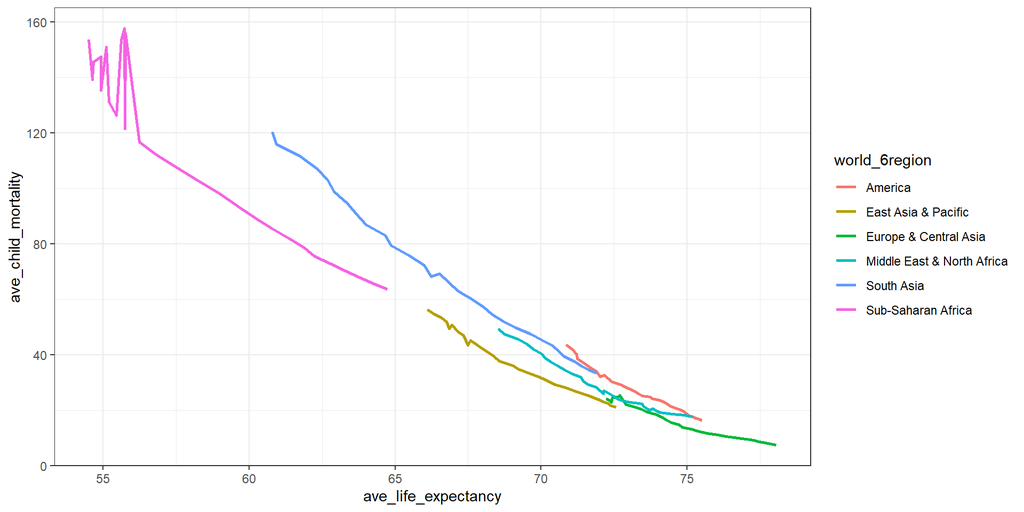

```r
select5 %>%
    group_by(year, world_6region) %>%
    summarize(
      ave_life_expectancy = mean(life_expectancy, na.rm = TRUE),
      ave_child_mortality = mean(child_mortality, na.rm = TRUE)
    ) %>%
  ggplot(aes(x=ave_life_expectancy, y=ave_child_mortality))+
      geom_line(aes(color=world_6region, group=world_6region), size=1) +
      theme_bw()
```

# 6 life_expectacy vs child_mortility

From the plot we made previously, we can find that the relationship between life expectancy and child mortality is when life expectancy increases, then child mortality decreases over time. Since the data was recorded from 1989 to 2018, the life expectancy of region Europe and Central Asia is highest over 75 with very low child mortality. However, sub-Saharan Africa is a different story, there is obvious data fluctuation at the beginning of the line, also, this region has a relatively lower life expectancy and higher child mortality than the rest of the world. This reflects some extent the economic and political situation of the region.

# 7 Making figures using life_expectacy vs child_mortility(weight=population)

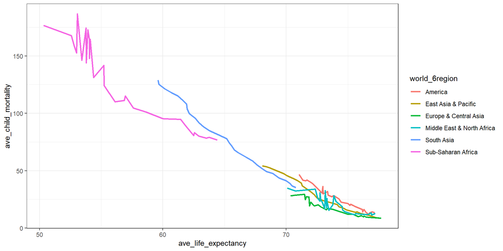

```r
select5 %>%
    group_by(year, world_6region) %>%
    summarize(
      ave_life_expectancy = weighted.mean(life_expectancy, w = as.numeric(population), na.rm = TRUE),
      ave_child_mortality = weighted.mean(child_mortality, w = as.numeric(population), na.rm = TRUE)
    ) %>%
  ggplot(aes(x=ave_life_expectancy, y=ave_child_mortality))+
      geom_line(aes(color=world_6region, group=world_6region), size=1) +
      theme_bw()
```

# 8 life_expectacy vs child_mortility(weight=population)

When we add the weight = population and redo this plot, we can get a similar plot like without weight. Still, when considering the case population, most regions have a high life expectancy and low child mortality. However, south Asia and Sub-Saharan Africa are two exceptional cases there, life expectancy in South Asia increased over 10 years in the time with a huge decrease in child mortality, in this case, those changes also can be found in Sub-Saharan Africa but there is still a lot of room for progress due to the poor base.

# 9 Final thoughts

When I generate my data, I observe that there are lots of NA data due to those numeric variables containing different periods such as the time for gdppc from 1799 to 2059 and murder total from 1989 to 2018. After collecting those data together, because of the year from 1799 to 2099, and for those years don’t have data, r mark NA in their positions. And this situations also happen for regions. As a result, if I want to generate plots or do research deeply, I should remove all the rows with NA, and finally the time only from 1989 to 2018.